Скачать ipynb

# [Введение в анализ данных](https://miptstats.github.io/courses/ad_fivt.html)

## PyTorch и полносвязные нейронные сети

[figure not shown]

### 1. Введение

В данном ноутбуке мы будем пользоваться фреймворком **PyTorch**, который предназначен для работы с нейронными сетями. Как установить `torch` можно прочитать [на официальном сайте PyTorch](http://pytorch.org/). Для этого выберите свою OS, и вам будет показана нужная команда для ввода в терминале. Больше подробностей о том, как работает `torch`, будет рассказано на 3 курсе.

```python
import numpy as np
import pandas as pd

import matplotlib.pyplot as plt
import seaborn as sns
from IPython.display import clear_output
sns.set(palette='Set2')

import torch
from torch import nn

print(torch.__version__)
```

```
2.1.0+cu121
```

#### 1.1 Сравнение NumPy и PyTorch-синтаксиса

Интерфейс `torch` написан подобно [интерфейсу](https://miptstats.github.io/courses/python/05_numpy.html) `numpy` для удобства использования. Главное различие между ними в том, что `numpy` оперирует `numpy.ndarray` массивами, а `torch` — тензорами `torch.Tensor`. Тензор в `torch`, как и массив в `numpy` представляет собой многомерную матрицу с элементами одного типа данных. Напишем одни и те же операции на `numpy` и `torch`.

**numpy**

```python
x = np.arange(16).reshape(4, 4)

print("Матрица X:\n{}\n".format(x))
print("Размер: {}\n".format(x.shape))
print("Добавление константы:\n{}\n".format(x + 5))
print("X*X^T:\n{}\n".format(np.dot(x, x.T)))
print("Среднее по колонкам:\n{}\n".format(x.mean(axis=-1)))
print("Кумулятивная сумма по колонкам:\n{}\n".format(np.cumsum(x, axis=0)))
```

```
Матрица X:
[[ 0  1  2  3]
 [ 4  5  6  7]
 [ 8  9 10 11]
 [12 13 14 15]]

Размер: (4, 4)

Добавление константы:
[[ 5  6  7  8]
 [ 9 10 11 12]
 [13 14 15 16]
 [17 18 19 20]]

X*X^T:
[[ 14  38  62  86]
 [ 38 126 214 302]
 [ 62 214 366 518]
 [ 86 302 518 734]]

Среднее по колонкам:
[ 1.5  5.5  9.5 13.5]

Кумулятивная сумма по колонкам:
[[ 0  1  2  3]
 [ 4  6  8 10]
 [12 15 18 21]
 [24 28 32 36]]
```

**pytorch**

```python
x = np.arange(16).reshape(4, 4)
x = torch.tensor(x, dtype=torch.float32)  # или torch.arange(0,16).view(4,4)

print("Матрица X:\n{}".format(x))
print("Размер: {}\n".format(x.shape))
print("Добавление константы:\n{}".format(x + 5))
print("X*X^T:\n{}".format(torch.matmul(x, x.transpose(1, 0))))  # кратко: x.mm(x.t())
print("Среднее по колонкам:\n{}".format(torch.mean(x, dim=-1)))
print("Кумулятивная сумма по колонкам:\n{}".format(torch.cumsum(x, dim=0)))
```

```
Матрица X:
tensor([[ 0.,  1.,  2.,  3.],
        [ 4.,  5.,  6.,  7.],
        [ 8.,  9., 10., 11.],
        [12., 13., 14., 15.]])
Размер: torch.Size([4, 4])

Добавление константы:
tensor([[ 5.,  6.,  7.,  8.],
        [ 9., 10., 11., 12.],
        [13., 14., 15., 16.],
        [17., 18., 19., 20.]])
X*X^T:
tensor([[ 14.,  38.,  62.,  86.],
        [ 38., 126., 214., 302.],
        [ 62., 214., 366., 518.],
        [ 86., 302., 518., 734.]])
Среднее по колонкам:
tensor([ 1.5000,  5.5000,  9.5000, 13.5000])
Кумулятивная сумма по колонкам:
tensor([[ 0.,  1.,  2.,  3.],
        [ 4.,  6.,  8., 10.],
        [12., 15., 18., 21.],
        [24., 28., 32., 36.]])
```

Все же некоторые названия методов отличаются от методов `numpy`. Полной совместимости с `numpy` пока нет, но от версии к версии разрыв сокращается, и придется снова запоминать новые названия для некоторых методов.

Например, PyTorch имеет другое написание стандартных типов

- `x.astype('int64') -> x.type(torch.LongTensor)`

Для более подробного ознакомления можно посмотреть на [табличку](https://github.com/torch/torch7/wiki/Torch-for-Numpy-users) перевода методов из `numpy` в `torch`, а также заглянуть в [документацию](http://pytorch.org/docs/master/). Также при возникновении проблем часто помогает зайти на [pytorch forumns](https://discuss.pytorch.org/).

#### 1.2 NumPy <-> PyTorch

Можно переводить `numpy`-массив в `torch`-тензор и наоборот. Например, чтобы сделать из `numpy`-массива `torch`-тензор, можно поступить следующим образом

```python
# зададим numpy массив
x_np = np.array([2, 5, 7, 1])

# 1-й способ
x_torch = torch.tensor(x_np)
print(type(x_torch), x_torch)

# 2-й способ
x_torch = torch.from_numpy(x_np)
print(type(x_torch), x_torch)
```

```
<class 'torch.Tensor'> tensor([2, 5, 7, 1])
<class 'torch.Tensor'> tensor([2, 5, 7, 1])
```

Аналогично и с переводом обратно: функция `x.numpy()` переведет `torch`-тензор `x` в `numpy`-массив, причем типы переведутся соответственно [табличке](https://github.com/torch/torch7/wiki/Torch-for-Numpy-users).

```python
x_np = x_torch.numpy()
print(type(x_np), x_np)
```

```
<class 'numpy.ndarray'> [2 5 7 1]
```

#### 1.3 Еще один пример

Нарисуем по сетке данную кривую на графике, используя `torch`:

$$x(t) = 2 \cos t + \sin 2t \cos 60t,$$$$y(t) = \sin 2t + \sin 60t.$$

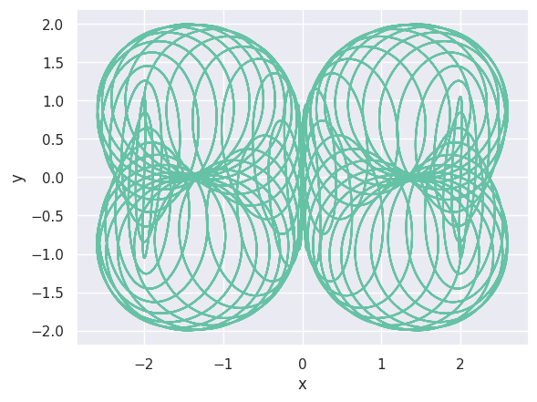

```python
t = torch.linspace(-10, 10, steps=10000)
x = 2 * torch.cos(t) + torch.sin(2 * t) * torch.cos(60 * t)
y = torch.sin(2 * t) + torch.sin(60 * t)

plt.plot(x, y)
plt.xlabel('x')
plt.ylabel('y')
plt.show()
```

Заметим, что библиотека `matplotlib` справляется с отображением `pytorch`-тензоров, и дополнительных преобразований делать не нужно.

### 2. Простой пример обучения нейронной сети

#### 2.1 Цикл обучения модели

Пусть задана нейронная сеть $f(x)$, параметризуемая обучаемыми параметрами $\theta$. Для входных данных $x$ модель возвращает $\widehat{y}=f(x)$. Для обучения модели необходимо задать оптимизируемую функцию (функцию ошибки, лосс) $L(y, \widehat{y})$, которую следует минимизировать.

Процесс обучения задается следующим образом.

- **Прямой проход / Forward pass:**  
  Считаем $\widehat{y}=f(x)$ для входных данных $x$.
- **Вычисление оптимизируемой функции:**  
  Вычисляем оптимизируемую функцию $L(y, \widehat{y})$.
- **Обратный проход / Backward pass:**  
  Считаем градиенты по всем обучаемым параметрам $\frac{\partial L}{\partial \theta}$.
- **Шаг оптимизации:**  
  Делаем шаг градиентного спуска, обновляя все обучаемые параметры.

#### 2.2 Линейная регрессия

В лекциях показано, что линейную регрессию можно представить как частный случай нейрона с тождественной функцией активации.

Сделаем одномерную линейную регрессию на датасете boston. Этот датасет представляет собой набор данных конца 70-х годов прошлого века для предсказания цены недвижимости в Бостоне.

Скачиваем данные.

```python
def load_boston():
    # ссылка для скачивания данных
    data_url = "http://lib.stat.cmu.edu/datasets/boston"
    # собираем таблицу данных
    raw_df = pd.read_csv(data_url, sep="\s+", skiprows=22, header=None)
    # выделяем признаки и таргет
    data = np.hstack([raw_df.values[::2, :], raw_df.values[1::2, :2]])
    target = raw_df.values[1::2, 2]
    return data, target
```

```python
data, target = load_boston()
```

Будем рассматривать зависимость таргета, т.е. медианной стоимости домов в тысячах долларов, от последнего признака, т.е. процента населения людей с низким уровнем дохода.

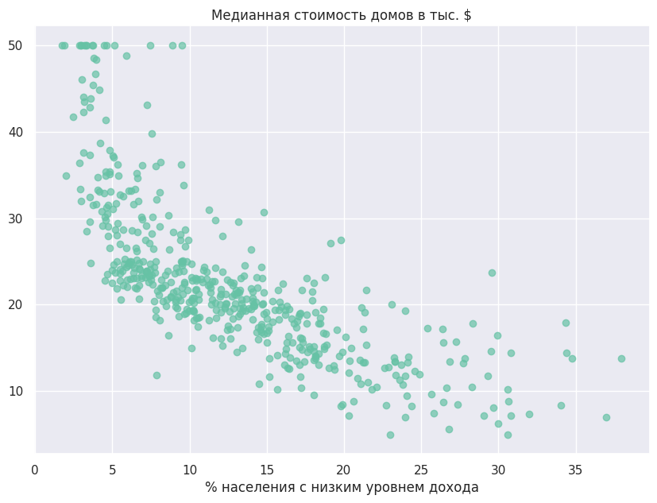

```python
plt.figure(figsize=(10, 7))
plt.scatter(data[:, -1], target, alpha=0.7)
plt.xlabel('% населения с низким уровнем дохода')
plt.title('Медианная стоимость домов в тыс. $');
```

В данном случае предсказание модели задается следующим образом: $$\widehat{y}(x) = wx + b,$$ где $w, b \in \mathbb{R}$ — обучаемые параметры модели. Это обычная линейная модель, и с ней мы уже работали [ранее](https://miptstats.github.io/courses/ad_fivt/linreg_sklearn.html).

Объявляем обучаемые параметры. Также задаем признак $X$ и таргет $Y$ в виде `torch`-тензоров.

```python
# создаем два тензора размера 1 с заполнением нулями,
# для которых будут вычисляться градиенты
w = torch.zeros(1, requires_grad=True)
b = torch.zeros(1, requires_grad=True)

# Данные оборачиваем в тензоры, по которым не требуем вычисления градиента
x = torch.FloatTensor(data[:, -1] / 10)
y = torch.FloatTensor(target)

# по-другому:
# x = torch.tensor(boston.data[:, -1] / 10, dtype=torch.float32)
# y = torch.tensor(boston.target, dtype=torch.float32)
```

```python
print(x.shape)
print(y.shape)
```

```
torch.Size([506])
torch.Size([506])
```

Зададим оптимизируемую функцию / функцию ошибки / лосс — [MSE](https://miptstats.github.io/courses/ad_fivt/linreg_sklearn.html#3.-Тестирование-и-оценка-качества):

$$ \mathrm{MSE}(\widehat{y}, y) = \frac{1}{n} \sum_{i=1}^n \left(\widehat{y}_i - y_i\right)^2. $$

```python
def optim_func(y_pred, y_true):
    return torch.mean((y_pred - y_true) ** 2)
```

После того, как мы посчитаем результат применения этой функции к нашим данным, нам необходимо посчитать градиенты по всем обучаемым параметрам, чтобы затем сделать шаг градиентного спуска. В этом нам поможет функция `backward`. Вызвав `backward` для результата подсчета функции ошибки `loss`, мы сделаем обратный проход по всему графу вычислений и посчитаем градиенты лосса по всем обучаемым параметрам. Подробнее о том, как это работает, будет рассказано на 3 курсе.

```python
# Прямой проход
y_pred = w * x + b

# Вычисление лосса
loss = optim_func(y_pred, y)

# Вычисление градиентов
# с помощью обратного прохода по сети
# и сохранение их в памяти сети
loss.backward()
```

Здесь `loss` — значение функции MSE, вычисленное на этой итерации.

```python
loss
```

```
tensor(592.1469, grad_fn=<MeanBackward0>)
```

К градиентам для обучаемых параметров, для которых `requires_grad=True`, теперь можно обратиться следующим образом:

```python
print("dL/dw =", w.grad)
print("dL/b =", b.grad)
```

```
dL/dw = tensor([-47.3514])
dL/b = tensor([-45.0656])
```

Если мы посчитаем градиент $M$ раз, то есть $M$ раз вызовем `loss.backward()`, то градиент будет накапливаться (суммироваться) в параметрах, требующих градиента. Иногда это бывает удобно.

Убедимся на примере, что именно так все и работает.

```python
y_pred = w * x + b
loss = optim_func(y_pred, y)
loss.backward()

print("dL/dw =", w.grad)
print("dL/b =", b.grad)
```

```
dL/dw = tensor([-94.7029])
dL/b = tensor([-90.1312])
```

Видим, что значения градиентов стали в 2 раза больше, за счет того, что мы сложили одни и те же градиенты 2 раза.

Если же мы не хотим, чтобы градиенты суммировались, то нужно **занулять градиенты** между итерациями после того как сделали шаг градиентного спуска. Это можно сделать с помощью функции `zero_` для градиентов.

```python
w.grad.zero_()
b.grad.zero_()
w.grad, b.grad
```

```
(tensor([0.]), tensor([0.]))
```

Соберем в единый пайплайн весь рассмотренный выше процесс для совершения нескольких итераций обучения. Также напишем функцию визуализации процесса обучения.

```python
def show_progress(x, y, y_pred, loss):
    '''
    Визуализация процесса обучения.

    x, y -- объекты и таргеты обучающей выборки;
    y_pred -- предсказания модели;
    loss -- текущее значение ошибки модели.
    '''

    # Открепим переменную от вычислительного графа перед отрисовкой графика
    y_pred = y_pred.detach()

    # Превратим тензор размерности 0 в число
    loss = loss.item()

    # Стираем предыдущий вывод в тот момент, когда появится следующий
    clear_output(wait=True)

    # Строим новый график
    plt.figure(figsize=(10, 7))
    plt.scatter(x, y, alpha=0.75)
    plt.scatter(x, y_pred, color='orange', linewidth=5)
    plt.xlabel('% населения с низким уровнем дохода')
    plt.title('Медианная стоимость домов в тыс. $')
    plt.show()

    print(f"MSE = {loss:.3f}")
```

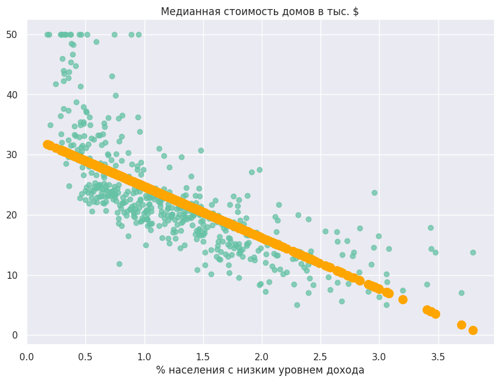

```
MSE = 38.978
Готово!
```

```python
# Инициализация параметров
w = torch.zeros(1, requires_grad=True)
b = torch.zeros(1, requires_grad=True)

# Количество итераций
num_iter = 1000

# Скорость обучения для параметров
lr_w = 0.01
lr_b = 0.05

for i in range(num_iter):

    # Forward pass: предсказание модели
    y_pred = w * x + b

    # Вычисление оптимизируемой функции (MSE)
    loss = optim_func(y_pred, y)

    # Обратный проход: вычисление градиентов
    loss.backward()

    # Оптимизация: обновление параметров
    w.data -= lr_w * w.grad.data
    b.data -= lr_b * b.grad.data

    # Зануление градиентов
    w.grad.zero_()
    b.grad.zero_()

    # График + вывод MSE через каждые 5 итераций
    if (i + 1) % 5 == 0:
        show_progress(x, y, y_pred, loss)

        if loss.item() < 39:
            print("Готово!")
            break
```

#### 2.3 Улучшение модели

Попробуем усложнить модель, добавив еще один слой. Тем самым модель примет следующий вид

$$\widehat{y}(x) = w_2u(x) + b_2,$$$$u(x) = \sigma(w_1x + b_1),$$$$\sigma(x) = \text{ReLU}(x) = \begin{equation*}\begin{cases}x, \; x \ge 0, \\ 0, \; \text{иначе,} \end{cases} \end{equation*}$$

$w_1, b_1 \in \mathbb{R}$ — обучаемые параметры первого слоя, $w_2, b_2 \in \mathbb{R}$ — обучаемые параметры второго слоя, $\sigma(x)$ — функция активации, в данном случае `ReLU`. Можно заметить, что эта функция не удовлетворяет условиям теоремы Цыбенко, тем не менее на практике она часто применяется для нейронных сетей.

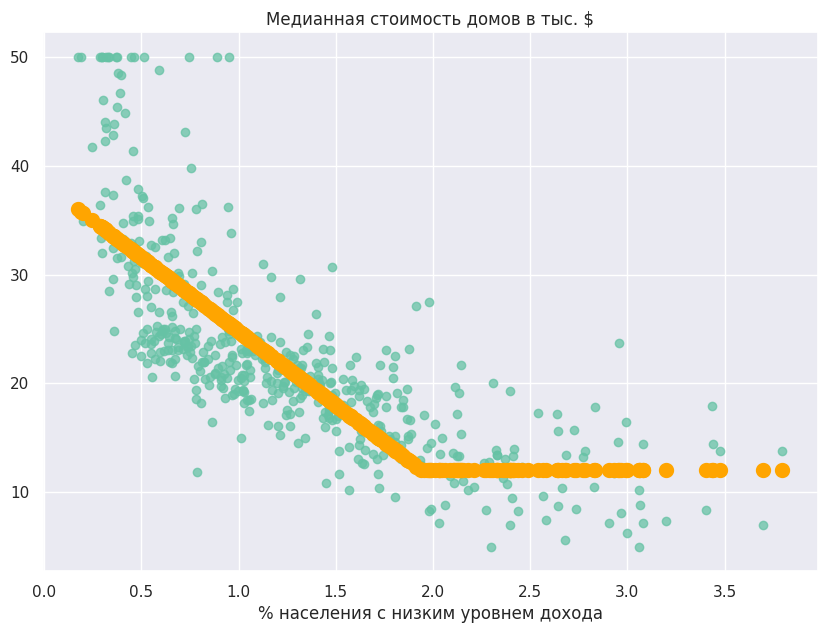

```
MSE = 32.994
Готово!
```

```python
# Инициализация параметров
w0 = torch.ones(1, requires_grad=True)
b0 = torch.ones(1, requires_grad=True)
w1 = torch.ones(1, requires_grad=True)
b1 = torch.ones(1, requires_grad=True)

# Функция активации
def act_func(x):
    return x * (x >= 0)

# Количество итераций
num_iter = 1000

# Скорость обучения для параметров
lr_w = 0.01
lr_b = 0.05

for i in range(num_iter):

    # Forward pass: предсказание модели
    y_pred = w1 * act_func(w0 * x + b0) + b1

    # Вычисление оптимизируемой функции (MSE)
    loss = optim_func(y_pred, y)

    # Bakcward pass: вычисление градиентов
    loss.backward()

    # Оптимизация: обновление параметров
    w0.data -= lr_w * w0.grad.data
    b0.data -= lr_b * b0.grad.data
    w1.data -= lr_w * w1.grad.data
    b1.data -= lr_b * b1.grad.data

    # Зануление градиентов
    w0.grad.zero_()
    b0.grad.zero_()
    w1.grad.zero_()
    b1.grad.zero_()

    # График + вывод MSE через каждые 5 итераций
    if (i + 1) % 5 == 0:
        show_progress(x, y, y_pred, loss)

        if loss.item() < 33:
            print("Готово!")
            break
```

Полученная модель лучше описывает данные, т.к. лосс стал меньше, и функция, которая получилась на выходе модели, оказалась ближе к точкам из данных на графике. Такой эффект вызвало добавление нелинейности в модель.

### 3. Готовые модули из PyTorch

На практике нейронные сети так не пишут, а пользуются готовыми модулями. Напишем такую же нейросеть, но теперь с помощью `torch`. Для этого будем пользоваться `torch.nn`.

Воспользуемся следующими модулями:

- `nn.Sequential` — модуль для соединения модулей последовательно, друг за другом;
- `nn.Linear` — модуль линейного слоя (без функции активации);
- `nn.ReLU` — модуль функции активации ReLU.

```python
# собираем модули в последовательность
model = nn.Sequential(
    # кол-во признаков во входном слое 1, в выходном тоже 1
    nn.Linear(in_features=1, out_features=1),
    # та же ф-ция активации, что и раньше, только из pytorch
    nn.ReLU(),
    # кол-во признаков во входном слое 1, в выходном тоже 1
    nn.Linear(in_features=1, out_features=1)
)

model
```

```
Sequential(
  (0): Linear(in_features=1, out_features=1, bias=True)
  (1): ReLU()
  (2): Linear(in_features=1, out_features=1, bias=True)
)
```

Для того, чтобы работать с данной моделью, нам необходимо поменять размерность `x` и `y`.

```python
x_new = x.reshape(-1, 1)
y_new = y.reshape(-1, 1)
```

Применим модель к нашим данным и посмотрим на результаты для первых 10 элементов.

```python
model(x_new)[:10]
```

```
tensor([[0.7237],
        [0.7951],
        [0.7074],
        [0.6887],
        [0.7297],
        [0.7276],
        [0.8515],
        [0.9668],
        [1.1518],
        [0.9316]], grad_fn=<SliceBackward0>)
```

Посмотрим на обучаемые параметры модели с помощью функции `named_parameters`, которая, кроме параметров, выдает также их названия. Имена `0.weight` и `0.bias` соответствуют весу $w_1$ и сдвигу $b_1$ первого слоя, аналогично, `2.weight` и `2.bias` соответствуют весу $w_2$ и сдвигу $b_2$ второго слоя.

```python
for name, param in model.named_parameters():
    print(name)
    print(param.data)
```

```
0.weight
tensor([[0.2941]])
0.bias
tensor([0.2293])
2.weight
tensor([[0.5835]])
2.bias
tensor([0.5044])
```

Заметим, что в названии параметров есть индексы $0$ и $2$, но нет индекса $1$, т.к. $0$-й и $2$-й модули в модели представлены линейными слоями, а $1$-й модуль — функцией активации, у которой нет обучаемых параметров.

Инициализируем параметры так же, как мы делали для подобной модели ранее. На этот раз воспользуемся функцией `parameters`, она возвращает только параметры.

```python
for p in model.parameters():
    p.data = torch.FloatTensor([[1]])
    print(p.data)
```

```
tensor([[1.]])
tensor([[1.]])
tensor([[1.]])
tensor([[1.]])
```

Ранее мы производили оптимизацию самостоятельно. Теперь же сделаем это с помощью оптимизатора `SGD` из `torch`, который реализует стохастический градиентный спуск. Он принимает на вход параметры модели, их мы можем получить, вызвав метод `parameters` у модели, и скорость обучения `lr`, которую мы обозначали ранее как $\eta$. У оптимизатора есть возможность задать некоторые другие аргументы, но их мы рассмотрим уже на 3 курсе.

Установим скорость обучения на уровне $0.01$ для всех параметров сразу. Также заменим нашу написанную `MSE` функцию на соответствующую из `torch`.

```python
optimizer = torch.optim.SGD(model.parameters(), lr=0.01)
optim_func = nn.MSELoss()
```

Обучим полученную модель на наших данных. Теперь обновления значений параметров происходят с помощью вызова `optimzer.step()`, а зануление градиентов — с помощью `optimizer.zero_grad()`.

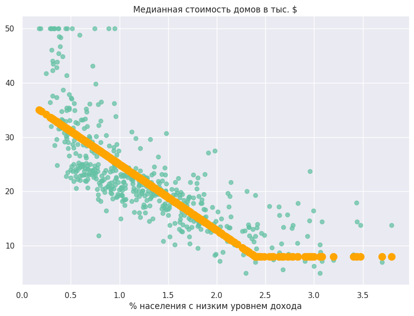

```
MSE = 34.986
Готово!
```

```python
# Количество итераций
num_iter = 10000

for i in range(num_iter):

    # Forward pass: предсказание модели по данным x_new
    y_pred = model(x_new)

    # Вычисление оптимизируемой функции (MSE) по предсказаниям
    loss = optim_func(y_pred, y_new)

    # Bakcward pass: вычисление градиентов оптимизируемой функции
    # по всем параметрам модели
    loss.backward()

    # Оптимизация: обновление параметров по формулам соответствующего
    # метода оптимизации, используются вычисленные ранее градиенты
    optimizer.step()

    # Зануление градиентов
    optimizer.zero_grad()

    # График + вывод MSE через каждые 5 итераций
    if (i + 1) % 5 == 0:
        show_progress(x, y, y_pred, loss)

        if loss.item() < 35:
            print("Готово!")
            break
```

Полученная модель довольно хорошо приближает данные, однако дольше сходится к оптимуму за счет меньшей скорости обучения для параметров сдвига.

Далее мы [посмотрим](https://miptstats.github.io/courses/ad_fivt/nn_complex_examples.html) примеры применения нейронных сетей на практике.